# Clase VIII: Algunas gráficas descriptivas

## Diagrama de dispersión discriminado

- Para observar el comportamiento de dos variables Cuantitativas y una categórica.
- Puntos en plano coordenado.
- Eje x: Variable independiente
- Eje y: Variable de respuesta
- Colores: variable categórica.

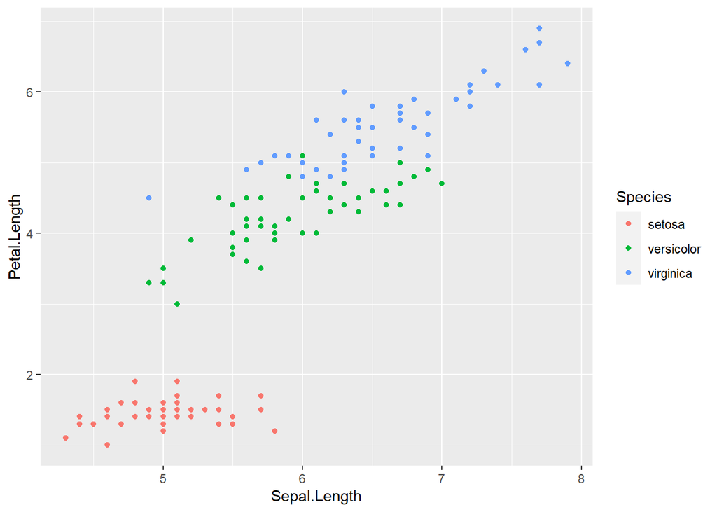

```r
ggplot(iris) +
  aes(x = Sepal.Length, y = Petal.Length, colour = Species) +
  geom_point() +
  scale_color_hue()
```

# Ejemplo 3

## Edad de muerte de los reyes

Examinemos una base de datos curiosa. Ésta contiene la edad que tenían varios reyes de Inglaterra en el momento de su fallecimiento.

```r
kings <- scan("http://robjhyndman.com/tsdldata/misc/kings.dat",skip=3)
kings
```

```
##  [1] 60 43 67 50 56 42 50 65 68 43 65 34 47 34 49 41 13 35 53 56 16 43 69 59 48
## [26] 59 86 55 68 51 33 49 67 77 81 67 71 81 68 70 77 56
```

## Gráfico de línea

Una manera de visualizar esta información es con los **gráficos de línea de tiempo**, también llamados **gráficos de series de tiempo**. Una forma sencilla de hacerlos es graficando una línea:

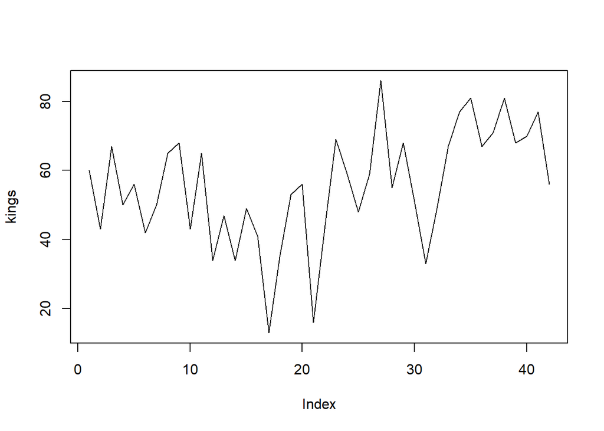

```r
plot(kings, type = 'l')
```

# Ejemplo 3: Lidiando con fechas

Tenemos un connunto de datos con las mediciones meteorológicas diarias de 2009 a 2011 de *NEON Harvard Forest field*. Examinemos como varía la temperatura del aire a través del tiempo. La variable de interés se llama `airt`.

Primero, importemos los datos.

```r
MetDiario.09.11 <- read.csv("Met_HARV_Daily_2009_2011.csv")
```

Ahora vamos a asegurarnos de que la columna que tiene la fecha sea interpretada por `R` como una fecha:

```r
MetDiario.09.11$date <- as.Date(MetDiario.09.11$date)
```

La librería **ggplot2** permite hacer gráficos de series de tiempo de forma muy flexible.

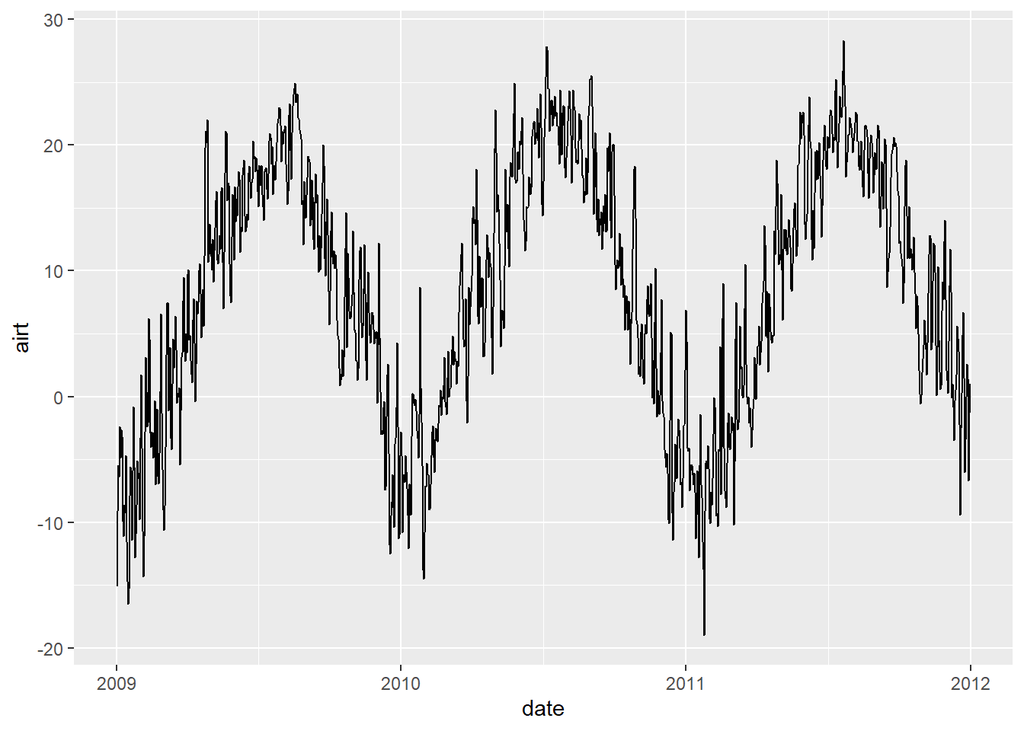

```r
ggplot(MetDiario.09.11, aes(date, airt)) + geom_line(na.rm=TRUE)
```

Si queremos tener en cuenta el detalle de los meses, debemos cambiar la escala del eje x.

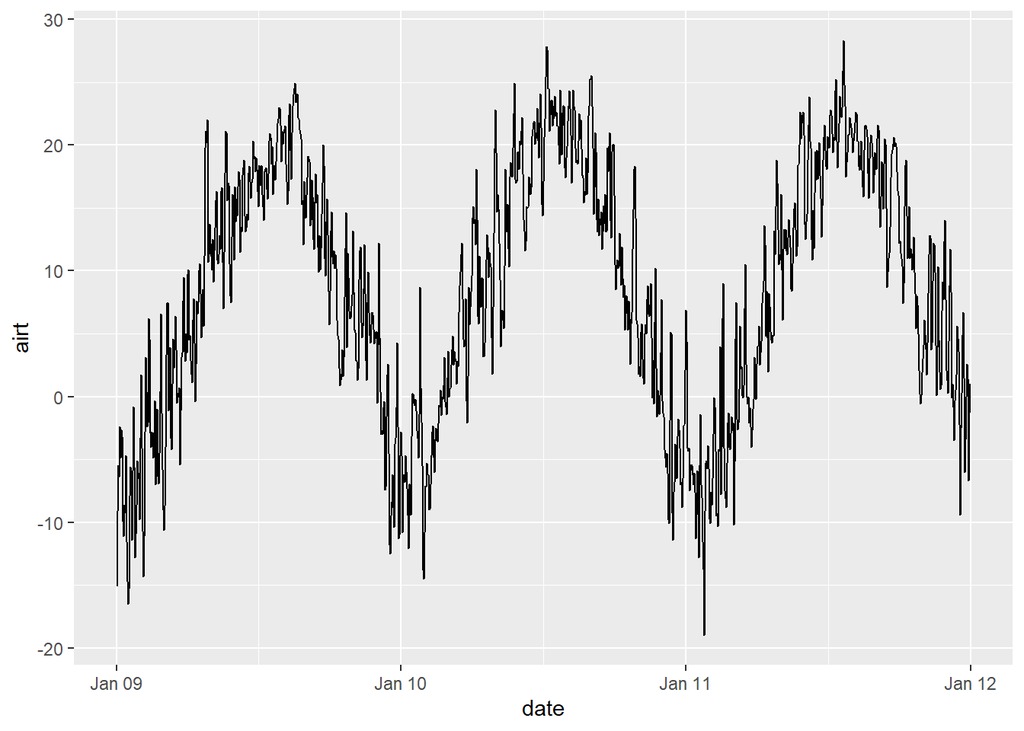

```r
# library(lubridate)
# library(scales)
ggplot(MetDiario.09.11, aes(date, airt)) + geom_line(na.rm=TRUE) +
  scale_x_date(labels=date_format("%b %y"))
```